# Research Guide

## Logical

#### F9_05_UBIZ_IMCOME_OVER_LIMIT_X

**LABEL**: F9_05_UBIZ_IMCOME_OVER_LIMIT_X

**DATA TYPE**: logical

**SCOPE**:

**LENGTH**: 1

**DESCRIPTION**: Had unrelated business gross income of $1,000 or more [x]

**LEVELS**:

| N | N |
| --- | --- |
| Y | Y |

**LOCATION CODE**:

**PROPERTIES**:

| STAT | VAL | PER |
| --- | --- | --- |
| Rows | 25000 |  |
| Distinct | 2 |  |
| Most Common Value | N | (86%) |
| Zero | 0 | (0%) |
| All Empty | 0 | (0%) |
| Missing/NA | 0 | (0%) |
| Infinite | 0 | (0%) |

**VALUES**:

| Value | Frequency |
| --- | --- |
| N | 21550 |
| Y | 3450 |

**BOOLPLOT**:

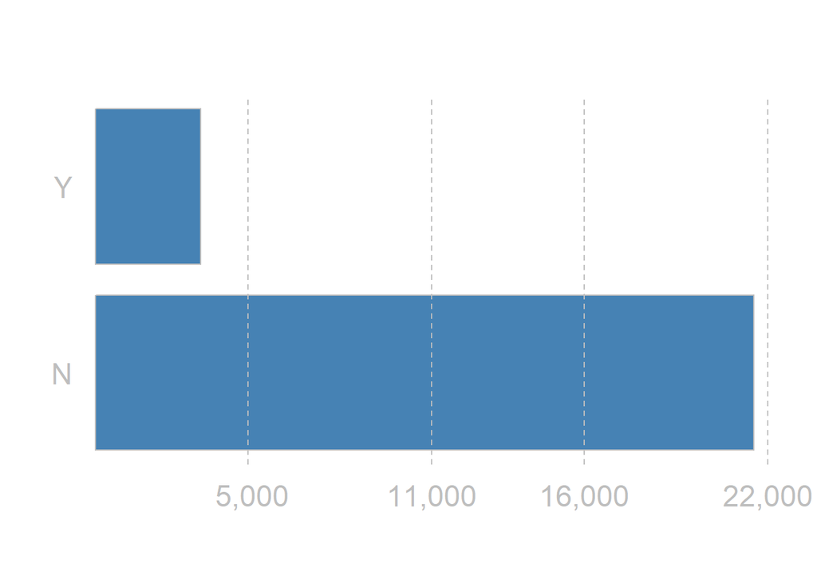

#### OUTNCCS

**LABEL**: OUTNCCS

**DATA TYPE**: logical

**SCOPE**:

**LENGTH**: 3

**DESCRIPTION**: Out of Scope flag

**LEVELS**:

| IN | IN |
| --- | --- |
| OUT | OUT |

**LOCATION CODE**:

**PROPERTIES**:

| STAT | VAL | PER |
| --- | --- | --- |
| Rows | 25000 |  |
| Distinct | 3 |  |
| Most Common Value | IN | (100%) |
| Zero | 0 | (0%) |
| All Empty | 0 | (0%) |
| Missing/NA | 2361 | (9.4%) |
| Infinite | 0 | (0%) |

**VALUES**:

| Value | Frequency |
| --- | --- |
| IN | 22600 |
| NA | 2361 |
| OUT | 39 |

**BOOLPLOT**:

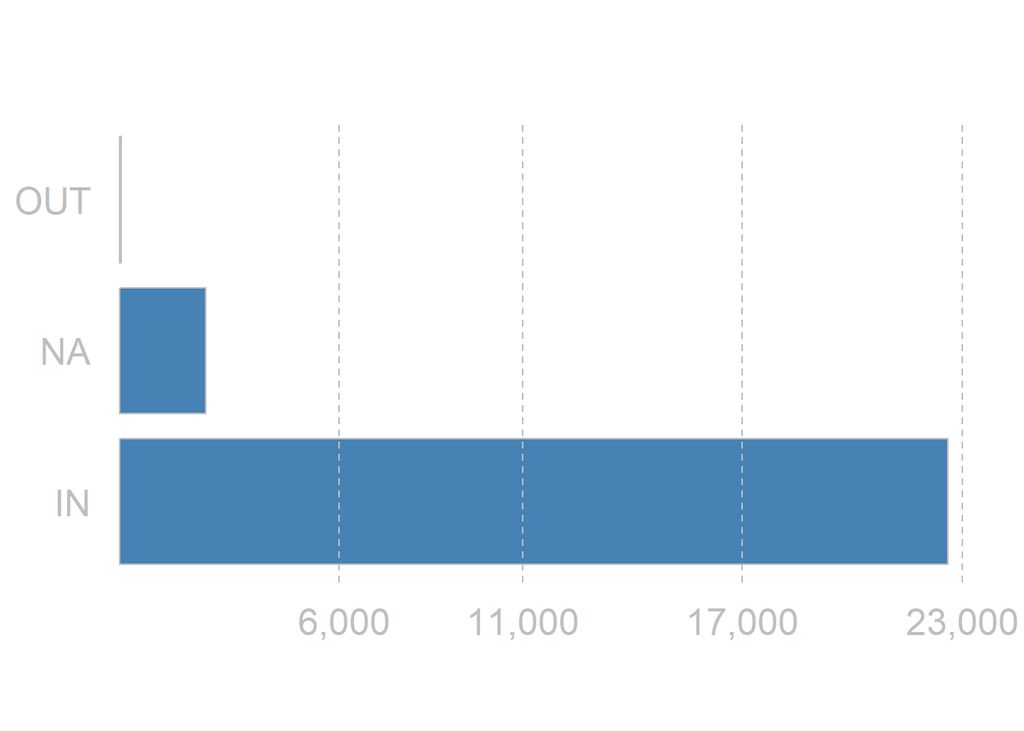

## Factor

#### SUBSECCD

**LABEL**: SUBSECCD

**DATA TYPE**: factor

**SCOPE**:

**LENGTH**: 2

**DESCRIPTION**: IRS subsection code

**LEVELS**:

| 2 | 2 |
| --- | --- |
| 4 | 4 |
| 5 | 5 |
| 6 | 6 |
| 7 | 7 |
| 8 | 8 |
| 9 | 9 |
| 10 | 10 |
| 11 | 11 |
| 12 | 12 |
| 13 | 13 |
| 14 | 14 |
| 15 | 15 |
| 16 | 16 |
| 17 | 17 |
| 18 | 18 |
| 19 | 19 |
| 23 | 23 |
| 24 | 24 |
| 25 | 25 |
| 26 | 26 |
| 27 | 27 |
| 29 | 29 |

**LOCATION CODE**:

**PROPERTIES**:

| STAT | VAL | PER |
| --- | --- | --- |
| Rows | 25000 |  |
| Distinct | 23 |  |
| Most Common Value | 6 | (26%) |
| Zero | 0 | (0%) |
| All Empty | 0 | (0%) |
| Missing/NA | 0 | (0%) |
| Infinite | 0 | (0%) |

**MOST COMMON VALUES**:

| Value | Frequency |
| --- | --- |
| 6 | 6391 |
| 4 | 4936 |
| 7 | 3571 |
| 5 | 3449 |
| 8 | 1479 |
| 19 | 1459 |

**TREEMAP**:

[figure not shown]

#### BMF_ACTIV1

**LABEL**: BMF_ACTIV1

**DATA TYPE**: factor

**SCOPE**:

**LENGTH**: 3

**DESCRIPTION**: IRS Activity Code 1

**LEVELS**:

| 263 | 263 |
| --- | --- |
| 200 | 200 |
| 379 | 379 |
| 0 | 0 |
| 407 | 407 |
| 907 | 907 |
| 321 | 321 |
| 40 | 40 |
| 520 | 520 |
| 260 | 260 |
| 211 | 211 |
| 205 | 205 |
| 264 | 264 |
| 284 | 284 |
| 280 | 280 |
| 318 | 318 |
| 36 | 36 |
| 399 | 399 |
| 402 | 402 |
| 919 | 919 |
| 900 | 900 |
| 160 | 160 |
| 265 | 265 |
| 319 | 319 |
| 230 | 230 |
| 286 | 286 |
| 279 | 279 |
| 229 | 229 |
| 905 | 905 |
| 59 | 59 |
| 328 | 328 |
| 382 | 382 |
| 908 | 908 |
| 561 | 561 |
| 179 | 179 |
| 911 | 911 |
| 261 | 261 |
| 213 | 213 |
| 250 | 250 |
| 912 | 912 |
| 317 | 317 |
| 288 | 288 |
| 999 | 999 |
| 32 | 32 |
| 281 | 281 |
| 300 | 300 |
| 998 | 998 |
| 285 | 285 |
| 381 | 381 |
| 901 | 901 |

**LOCATION CODE**:

**PROPERTIES**:

| STAT | VAL | PER |
| --- | --- | --- |
| Rows | 25000 |  |
| Distinct | 230 |  |
| Most Common Value | 0 | (25%) |
| Zero | 5807 | (23.2%) |
| All Empty | 0 | (0%) |
| Missing/NA | 1887 | (7.5%) |
| Infinite | 0 | (0%) |

**MOST COMMON VALUES**:

| Value | Frequency |
| --- | --- |
| 0 | 5807 |
| 263 | 1782 |
| 200 | 1648 |
| 907 | 1212 |
| 36 | 1054 |
| 279 | 998 |

**TREEMAP**:

[figure not shown]

#### NTMAJ12

**LABEL**: NTMAJ12

**DATA TYPE**: factor

**SCOPE**:

**LENGTH**: 2

**DESCRIPTION**: NTEE major group (12)

**LEVELS**:

| AR | AR |
| --- | --- |
| BH | BH |
| ED | ED |
| EH | EH |
| EN | EN |
| HE | HE |
| HU | HU |
| IN | IN |
| MU | MU |
| PU | PU |
| RE | RE |
| UN | UN |

**LOCATION CODE**:

**PROPERTIES**:

| STAT | VAL | PER |
| --- | --- | --- |
| Rows | 25000 |  |
| Distinct | 12 |  |
| Most Common Value | PU | (37%) |
| Zero | 0 | (0%) |
| All Empty | 0 | (0%) |
| Missing/NA | 0 | (0%) |
| Infinite | 0 | (0%) |

**MOST COMMON VALUES**:

| Value | Frequency |
| --- | --- |
| PU | 9128 |
| HU | 7955 |
| MU | 2480 |
| ED | 1528 |
| UN | 1524 |
| HE | 994 |

**TREEMAP**:

[figure not shown]

#### NTEE1

**LABEL**: NTEE1

**DATA TYPE**: factor

**SCOPE**:

**LENGTH**: 1

**DESCRIPTION**: NTEE major group

**LEVELS**:

| A | A |
| --- | --- |
| B | B |
| C | C |
| D | D |
| E | E |
| F | F |
| G | G |
| H | H |
| I | I |
| J | J |
| K | K |
| L | L |
| M | M |
| N | N |
| O | O |
| P | P |
| Q | Q |
| R | R |
| S | S |
| T | T |
| U | U |
| V | V |
| W | W |
| X | X |
| Y | Y |
| Z | Z |

**LOCATION CODE**:

**PROPERTIES**:

| STAT | VAL | PER |
| --- | --- | --- |
| Rows | 25000 |  |
| Distinct | 27 |  |
| Most Common Value | S | (25%) |
| Zero | 0 | (0%) |
| All Empty | 0 | (0%) |
| Missing/NA | 1497 | (6%) |
| Infinite | 0 | (0%) |

**MOST COMMON VALUES**:

| Value | Frequency |
| --- | --- |
| S | 5817 |
| N | 3018 |
| W | 2835 |
| Y | 2480 |
| J | 1961 |
| B | 1552 |

**TREEMAP**:

[figure not shown]

#### NTEEFINAL

**LABEL**: NTEEFINAL

**DATA TYPE**: factor

**SCOPE**:

**LENGTH**: 5

**DESCRIPTION**:

**LEVELS**:

| J40 | J40 |
| --- | --- |
| S41 | S41 |
| K28 | K28 |
| N61 | N61 |
| S47 | S47 |
| M24 | M24 |
| S80 | S80 |
| W30 | W30 |
| S03 | S03 |
| N68 | N68 |
| L11 | L11 |
| B82 | B82 |
| A30 | A30 |
| Y42 | Y42 |
| Y0120 | Y0120 |
| D60 | D60 |
| D03 | D03 |
| Y20 | Y20 |
| N50 | N50 |
| N60 | N60 |
| Y23 | Y23 |
| S22 | S22 |
| E11 | E11 |
| N66 | N66 |
| B40 | B40 |
| Y41 | Y41 |
| L50 | L50 |
| S21 | S21 |
| Y43 | Y43 |
| Y50 | Y50 |
| P82 | P82 |
| A80 | A80 |
| E80 | E80 |
| D40 | D40 |
| N6A | N6A |
| S20 | S20 |
| G30 | G30 |
| Z99 | Z99 |
| X22 | X22 |
| J20 | J20 |
| M03 | M03 |
| E99 | E99 |
| Y01 | Y01 |
| N64 | N64 |
| N69 | N69 |
| S01 | S01 |
| N40 | N40 |
| L20 | L20 |
| Y03 | Y03 |
| B83 | B83 |

**LOCATION CODE**:

**PROPERTIES**:

| STAT | VAL | PER |
| --- | --- | --- |
| Rows | 25000 |  |
| Distinct | 654 |  |
| Most Common Value | S41 | (8%) |
| Zero | 0 | (0%) |
| All Empty | 0 | (0%) |
| Missing/NA | 1497 | (6%) |
| Infinite | 0 | (0%) |

**MOST COMMON VALUES**:

| Value | Frequency |
| --- | --- |
| S41 | 1947 |
| J40 | 1815 |
| W30 | 1582 |
| S80 | 1515 |
| N50 | 1088 |
| M24 | 810 |

**TREEMAP**:

[figure not shown]

#### NTEESRC

**LABEL**: NTEESRC

**DATA TYPE**: factor

**SCOPE**:

**LENGTH**: 4

**DESCRIPTION**:

**LEVELS**:

| ACT1 | ACT1 |
| --- | --- |
| BEST | BEST |
| END2 | END2 |
| HIED | HIED |
| IRS | IRS |
| NEW | NEW |
| ntCO | ntCO |
| SOI | SOI |
| SUB | SUB |
| SUB2 | SUB2 |
| SUB3 | SUB3 |
| thp | thp |
| VER | VER |
| WORD | WORD |
| ZZ | ZZ |

**LOCATION CODE**:

**PROPERTIES**:

| STAT | VAL | PER |
| --- | --- | --- |
| Rows | 25000 |  |
| Distinct | 16 |  |
| Most Common Value | BEST | (53%) |
| Zero | 0 | (0%) |
| All Empty | 0 | (0%) |
| Missing/NA | 1378 | (5.5%) |
| Infinite | 0 | (0%) |

**MOST COMMON VALUES**:

| Value | Frequency |
| --- | --- |
| BEST | 12410 |
| WORD | 4000 |
| NEW | 2621 |
| IRS | 2540 |
| SOI | 855 |
| ZZ | 454 |

**TREEMAP**:

[figure not shown]

#### DEDUCTCD

**LABEL**: DEDUCTCD

**DATA TYPE**: factor

**SCOPE**:

**LENGTH**: 1

**DESCRIPTION**: IRS Deductibility code

**LEVELS**:

| 0 | 0 |
| --- | --- |
| 1 | 1 |
| 2 | 2 |
| 4 | 4 |

**LOCATION CODE**:

**PROPERTIES**:

| STAT | VAL | PER |
| --- | --- | --- |
| Rows | 25000 |  |
| Distinct | 5 |  |
| Most Common Value | 2 | (80%) |
| Zero | 685 | (2.7%) |
| All Empty | 0 | (0%) |
| Missing/NA | 1887 | (7.5%) |
| Infinite | 0 | (0%) |

**MOST COMMON VALUES**:

| Value | Frequency |
| --- | --- |
| 2 | 18494 |
| 1 | 3932 |
| 0 | 685 |
| 4 | 2 |

**TREEMAP**:

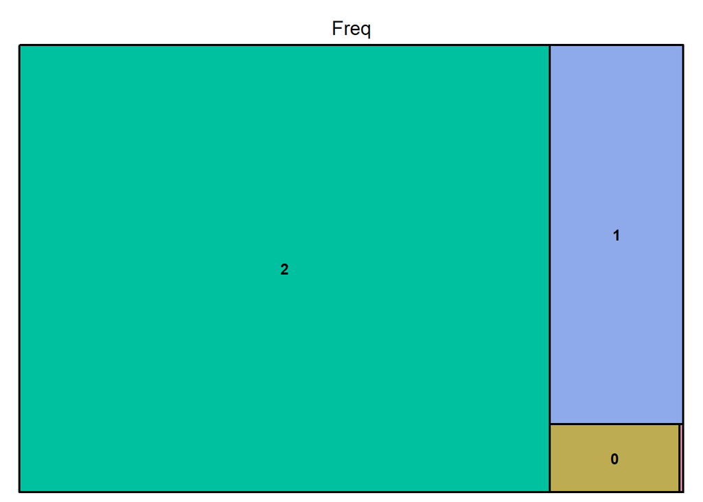

#### OUTREAS

**LABEL**: OUTREAS

**DATA TYPE**: factor

**SCOPE**:

**LENGTH**: 1

**DESCRIPTION**: Reason why out of scope

**LEVELS**:

| F | F |
| --- | --- |
| N | N |
| S | S |
| T | T |

**LOCATION CODE**:

**PROPERTIES**:

| STAT | VAL | PER |
| --- | --- | --- |
| Rows | 25000 |  |
| Distinct | 5 |  |
| Most Common Value | NA | (NaN%) |
| Zero | 0 | (0%) |
| All Empty | 0 | (0%) |
| Missing/NA | 24961 | (99.8%) |
| Infinite | 0 | (0%) |

**MOST COMMON VALUES**:

| Value | Frequency |
| --- | --- |
| T | 15 |
| F | 12 |
| S | 11 |
| N | 1 |

**TREEMAP**:

[figure not shown]

#### F9_00_TAX_PERIOD_END_DATE

**LABEL**: F9_00_TAX_PERIOD_END_DATE

**DATA TYPE**: factor

**SCOPE**:

**LENGTH**: 7

**DESCRIPTION**: Tax period end date

**LEVELS**:

| 201701 | 201701 |
| --- | --- |
| 201702 | 201702 |
| 201703 | 201703 |
| 201704 | 201704 |
| 201705 | 201705 |
| 201706 | 201706 |
| 201707 | 201707 |
| 201708 | 201708 |
| 201709 | 201709 |
| 201710 | 201710 |
| 201711 | 201711 |
| 201712 | 201712 |
| 201801 | 201801 |
| 201802 | 201802 |
| 201803 | 201803 |
| 201804 | 201804 |
| 201805 | 201805 |
| 201806 | 201806 |
| 201807 | 201807 |
| 201808 | 201808 |
| 201809 | 201809 |
| 201810 | 201810 |
| 201811 | 201811 |
| 201812 | 201812 |
| 201901 | 201901 |
| 201902 | 201902 |
| 201903 | 201903 |
| 201904 | 201904 |
| 201905 | 201905 |
| 201906 | 201906 |
| 201907 | 201907 |
| 201908 | 201908 |
| 201909 | 201909 |
| 201910 | 201910 |
| 201911 | 201911 |
| 201912 | 201912 |
| 202001 | 202001 |
| 202002 | 202002 |
| 202003 | 202003 |
| 202004 | 202004 |
| 202005 | 202005 |
| 202006 | 202006 |
| 202007 | 202007 |
| 202008 | 202008 |
| 202009 | 202009 |
| 202010 | 202010 |
| 202011 | 202011 |

**LOCATION CODE**:

**PROPERTIES**:

| STAT | VAL | PER |
| --- | --- | --- |
| Rows | 25000 |  |
| Distinct | 47 |  |
| Most Common Value | 2019-12 | (40%) |
| Zero | 0 | (0%) |
| All Empty | 0 | (0%) |
| Missing/NA | 0 | (0%) |
| Infinite | 0 | (0%) |

**MOST COMMON VALUES**:

| Value | Frequency |
| --- | --- |
| 2019-12 | 9884 |
| 2018-12 | 3477 |
| 2019-06 | 2064 |
| 2017-12 | 1626 |
| 2020-06 | 1312 |
| 2018-06 | 840 |

**TREEMAP**:

[figure not shown]

#### F9_00_TAX_PERIOD_END_DATE_PY

**LABEL**: F9_00_TAX_PERIOD_END_DATE_PY

**DATA TYPE**: factor

**SCOPE**:

**LENGTH**: 7

**DESCRIPTION**: Tax period end date - prior year

**LEVELS**:

| 201601 | 201601 |
| --- | --- |
| 201602 | 201602 |
| 201603 | 201603 |
| 201604 | 201604 |
| 201605 | 201605 |
| 201606 | 201606 |
| 201607 | 201607 |
| 201608 | 201608 |
| 201609 | 201609 |
| 201610 | 201610 |
| 201611 | 201611 |
| 201612 | 201612 |
| 201701 | 201701 |
| 201702 | 201702 |
| 201703 | 201703 |
| 201704 | 201704 |
| 201705 | 201705 |
| 201706 | 201706 |
| 201707 | 201707 |
| 201708 | 201708 |
| 201709 | 201709 |
| 201710 | 201710 |
| 201711 | 201711 |
| 201712 | 201712 |
| 201801 | 201801 |
| 201802 | 201802 |
| 201803 | 201803 |
| 201804 | 201804 |
| 201805 | 201805 |
| 201806 | 201806 |
| 201807 | 201807 |
| 201808 | 201808 |
| 201809 | 201809 |
| 201810 | 201810 |
| 201811 | 201811 |
| 201812 | 201812 |
| 201901 | 201901 |
| 201902 | 201902 |
| 201903 | 201903 |
| 201904 | 201904 |
| 201905 | 201905 |
| 201906 | 201906 |
| 201907 | 201907 |
| 201908 | 201908 |
| 201909 | 201909 |
| 201910 | 201910 |

**LOCATION CODE**:

**PROPERTIES**:

| STAT | VAL | PER |
| --- | --- | --- |
| Rows | 25000 |  |
| Distinct | 47 |  |
| Most Common Value | 2018-12 | (45%) |
| Zero | 0 | (0%) |
| All Empty | 0 | (0%) |
| Missing/NA | 4344 | (17.4%) |
| Infinite | 0 | (0%) |

**MOST COMMON VALUES**:

| Value | Frequency |
| --- | --- |
| 2018-12 | 9298 |
| 2017-12 | 3002 |
| 2018-06 | 1767 |
| 2019-06 | 1060 |
| 2018-09 | 744 |
| 2017-06 | 539 |

**TREEMAP**:

[figure not shown]

#### F9_00_TAX_ACCPER

**LABEL**: F9_00_TAX_ACCPER

**DATA TYPE**: factor

**SCOPE**:

**LENGTH**: 2

**DESCRIPTION**: Tax period end date

**LEVELS**:

| 1 | 1 |
| --- | --- |
| 2 | 2 |
| 3 | 3 |
| 4 | 4 |
| 5 | 5 |
| 6 | 6 |
| 7 | 7 |
| 8 | 8 |
| 9 | 9 |
| 10 | 10 |
| 11 | 11 |
| 12 | 12 |

**LOCATION CODE**:

**PROPERTIES**:

| STAT | VAL | PER |
| --- | --- | --- |
| Rows | 25000 |  |
| Distinct | 12 |  |
| Most Common Value | 12 | (60%) |
| Zero | 0 | (0%) |
| All Empty | 0 | (0%) |
| Missing/NA | 0 | (0%) |
| Infinite | 0 | (0%) |

**MOST COMMON VALUES**:

| Value | Frequency |
| --- | --- |
| 12 | 14987 |
| 06 | 4578 |
| 09 | 1251 |
| 03 | 849 |
| 05 | 796 |
| 08 | 688 |

**TREEMAP**:

[figure not shown]

## Numeric

#### COUNTY_FIPS

**LABEL**: COUNTY_FIPS

**DATA TYPE**: numeric

**SCOPE**:

**LENGTH**: 5

**DESCRIPTION**: State + County FIPS code

**LOCATION CODE**:

**PROPERTIES**:

| STAT | VAL | PER |
| --- | --- | --- |
| Rows | 25000 |  |
| Distinct | 2411 |  |
| Most Common Value | NA | (NaN%) |
| Zero | 0 | (0%) |
| All Empty | 0 | (0%) |
| Missing/NA | 2389 | (9.6%) |
| Infinite | 0 | (0%) |

**QUANTILES**:

| STAT | VAL |
| --- | --- |
| Q - 05 | 6,019 |
| Q - 25 | 17,027 |
| Median | 27,163 |
| Q - 75 | 41,051 |
| Q - 95 | 53,033 |

**STATS**:

| STAT | VAL |
| --- | --- |
| Minimum | 1,001 |
| Median | 27,163 |
| Mean | 28,405.45 |
| Maximum | 78,030 |
| Skew | -0.01 |

**HIST**:

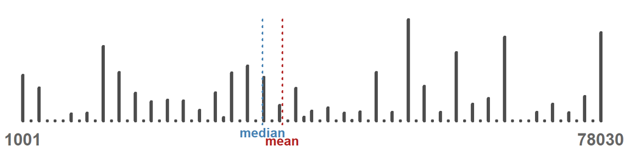

**DATA PREVIEW**:

| 18097 | 36119 |
| --- | --- |
| 9001 | 36029 |
| 6013 | 36103 |
| 19153 | 36059 |
| 36061 | 51059 |
| 6037 | 13121 |
| 4013 | 15003 |
| 6001 | 26125 |
| 11001 | 29189 |
| 39035 | 48453 |

#### CEO_CENSUSTRACT

**LABEL**: CEO_CENSUSTRACT

**DATA TYPE**: numeric

**SCOPE**:

**LENGTH**: 11

**DESCRIPTION**: Census tract

**LOCATION CODE**:

**PROPERTIES**:

| STAT | VAL | PER |
| --- | --- | --- |
| Rows | 25000 |  |
| Distinct | 14265 |  |
| Most Common Value | NA | (NaN%) |
| Zero | 0 | (0%) |
| All Empty | 0 | (0%) |
| Missing/NA | 3110 | (12.4%) |
| Infinite | 0 | (0%) |

**QUANTILES**:

| STAT | VAL |
| --- | --- |
| Q - 05 | 6,029,003,250 |
| Q - 25 | 17,031,320,100 |
| Median | 28,012,950,350 |
| Q - 75 | 41,051,008,202 |
| Q - 95 | 53,033,008,055 |

**STATS**:

| STAT | VAL |
| --- | --- |
| Minimum | 1,001,020,500 |
| Median | 28,012,950,350 |
| Mean | 28,488,147,053 |
| Maximum | 5.6043e+10 |
| Skew | -0.02 |

**HIST**:

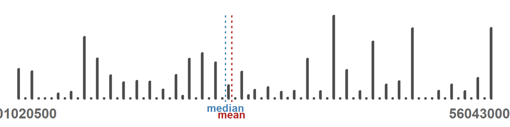

**DATA PREVIEW**:

| 6067001101 | 6073020809 |
| --- | --- |
| 48113020300 | 18097391000 |
| 28049010500 | 51510201900 |
| 6075011700 | 350 |
| 6037294421 | 11001010700 |
| 11001010100 | 42003020100 |
| 17031320100 | 11001005900 |
| 6075061500 | 17031839100 |
| 1097003707 | 22033003501 |
| 39049004000 | 6085512100 |

#### F9_08_REV_TOT_TOT

**LABEL**: F9_08_REV_TOT_TOT

**DATA TYPE**: numeric

**SCOPE**:

**LENGTH**: 10

**DESCRIPTION**: Total revenue - total

**LOCATION CODE**:

**PROPERTIES**:

| STAT | VAL | PER |
| --- | --- | --- |
| Rows | 25000 |  |
| Distinct | 23817 |  |
| Most Common Value | 0 | (2%) |
| Zero | 413 | (1.7%) |
| All Empty | 0 | (0%) |
| Missing/NA | 0 | (0%) |
| Infinite | 0 | (0%) |

**QUANTILES**:

| STAT | VAL |
| --- | --- |
| Q - 05 | 3,359.8 |
| Q - 25 | 51,012.5 |
| Median | 130,545 |
| Q - 75 | 441,954.5 |
| Q - 95 | 6,355,357 |

**STATS**:

| STAT | VAL |
| --- | --- |
| Minimum | -61,467,591 |
| Median | 130,545 |
| Mean | 3,740,777 |
| Maximum | 4,178,522,311 |
| Skew | 44.03 |

**HIST**:

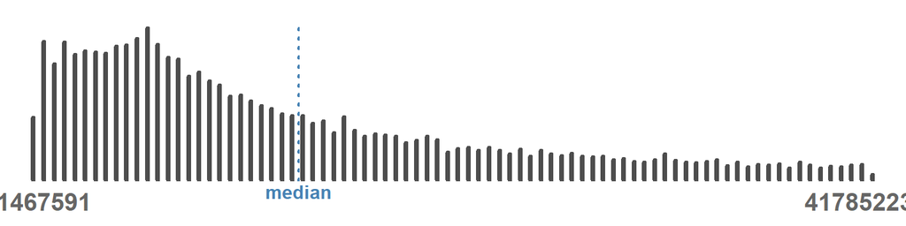

**DATA PREVIEW**:

| 9 | 20649 |
| --- | --- |
| 19611 | 9500 |
| 1500 | 48000 |
| 2000 | 9465 |
| 8 | 8800 |
| 75000 | 1 |
| 4125 | 1200 |
| 200 | 46814 |
| 250000 | 5 |
| 4 | 5400 |

#### F9_10_ASSET_TOT_BOY

**LABEL**: F9_10_ASSET_TOT_BOY

**DATA TYPE**: numeric

**SCOPE**:

**LENGTH**: 11

**DESCRIPTION**: Total assets - beginning of year

**LOCATION CODE**:

**PROPERTIES**:

| STAT | VAL | PER |
| --- | --- | --- |
| Rows | 25000 |  |
| Distinct | 20195 |  |
| Most Common Value | 0 | (13%) |
| Zero | 3011 | (12%) |
| All Empty | 0 | (0%) |
| Missing/NA | 1377 | (5.5%) |
| Infinite | 0 | (0%) |

**QUANTILES**:

| STAT | VAL |
| --- | --- |
| Q - 05 | 0 |
| Q - 25 | 31,558.5 |
| Median | 169,734 |
| Q - 75 | 729,844.5 |
| Q - 95 | 13,488,117 |

**STATS**:

| STAT | VAL |
| --- | --- |
| Minimum | -69,049 |
| Median | 169,734 |
| Mean | 11,116,959 |
| Maximum | 11,226,543,829 |
| Skew | 41.82 |

**HIST**:

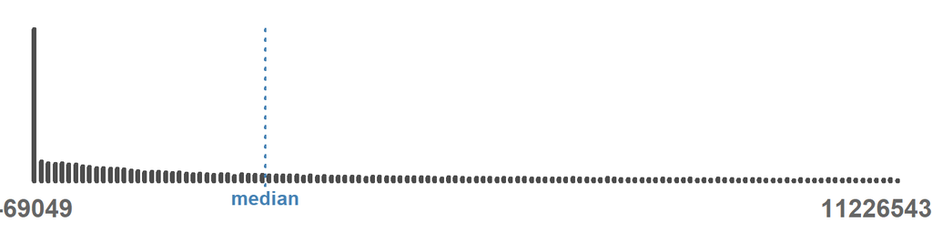

**DATA PREVIEW**:

| 1 | 2745 |
| --- | --- |
| 2155 | 0 |
| 6865 | 4414 |
| 4612 | 5761 |
| 343 | 718 |
| 1020 | 1607 |
| 6812 | 500 |
| 8528 | 219 |
| 9369 | 8451 |
| 9083 | 43506 |

#### F9_10_ASSET_TOT_EOY

**LABEL**: F9_10_ASSET_TOT_EOY

**DATA TYPE**: numeric

**SCOPE**:

**LENGTH**: 11

**DESCRIPTION**: Total assets - end of year

**LOCATION CODE**:

**PROPERTIES**:

| STAT | VAL | PER |
| --- | --- | --- |
| Rows | 25000 |  |
| Distinct | 24122 |  |
| Most Common Value | 1 | (1%) |
| Zero | 110 | (0.4%) |
| All Empty | 0 | (0%) |
| Missing/NA | 0 | (0%) |
| Infinite | 0 | (0%) |

**QUANTILES**:

| STAT | VAL |
| --- | --- |
| Q - 05 | 4,421.45 |
| Q - 25 | 55,668.25 |
| Median | 212,649 |
| Q - 75 | 837,286 |
| Q - 95 | 14,639,755 |

**STATS**:

| STAT | VAL |
| --- | --- |
| Minimum | -1,119,570 |
| Median | 212,649 |
| Mean | 13,755,826 |
| Maximum | 38,468,314,242 |
| Skew | 85.67 |

**HIST**:

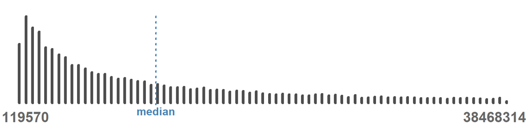

**DATA PREVIEW**:

| 3000 | 680 |
| --- | --- |
| 1 | 480 |
| 912 | 15000 |
| 10000 | 663 |
| 100 | 39 |
| 340 | 163 |
| 281 | 1158 |
| 37977 | 149 |
| 249 | 997 |
| 200 | 248 |

#### F9_10_NAFB_TOT_BOY

**LABEL**: F9_10_NAFB_TOT_BOY

**DATA TYPE**: numeric

**SCOPE**:

**LENGTH**: 10

**DESCRIPTION**: Net assets or fund balances - beginning of year

**LOCATION CODE**:

**PROPERTIES**:

| STAT | VAL | PER |
| --- | --- | --- |
| Rows | 25000 |  |
| Distinct | 20145 |  |
| Most Common Value | NA | (NaN%) |
| Zero | 203 | (0.8%) |
| All Empty | 0 | (0%) |
| Missing/NA | 4344 | (17.4%) |
| Infinite | 0 | (0%) |

**QUANTILES**:

| STAT | VAL |
| --- | --- |
| Q - 05 | 1,659.5 |
| Q - 25 | 52,689.5 |
| Median | 192,629.5 |
| Q - 75 | 720,262.5 |
| Q - 95 | 10,744,071 |

**STATS**:

| STAT | VAL |
| --- | --- |
| Minimum | -333,005,908 |
| Median | 192,629.5 |
| Mean | 4,921,982 |
| Maximum | 6,323,689,488 |
| Skew | 61.69 |

**HIST**:

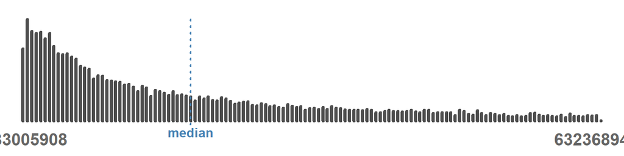

**DATA PREVIEW**:

| 5619 | 6141 |
| --- | --- |
| 6865 | 300 |
| 212 | 3554 |
| 4772 | 6812 |
| 7177 | 9369 |
| 0 | 3306 |
| -989 | 1593 |
| 3068 | 3087 |
| 718 | 1642 |
| 388 | 9527 |

#### F9_09_EXP_TOT_TOT

**LABEL**: F9_09_EXP_TOT_TOT

**DATA TYPE**: numeric

**SCOPE**:

**LENGTH**: 10

**DESCRIPTION**: Total functional expenses - total expenses

**LOCATION CODE**:

**PROPERTIES**:

| STAT | VAL | PER |
| --- | --- | --- |
| Rows | 25000 |  |
| Distinct | 23740 |  |
| Most Common Value | 0 | (2%) |
| Zero | 489 | (2%) |
| All Empty | 0 | (0%) |
| Missing/NA | 0 | (0%) |
| Infinite | 0 | (0%) |

**QUANTILES**:

| STAT | VAL |
| --- | --- |
| Q - 05 | 3,886.95 |
| Q - 25 | 46,845 |
| Median | 121,792.5 |
| Q - 75 | 411,837.2 |
| Q - 95 | 5,832,724 |

**STATS**:

| STAT | VAL |
| --- | --- |
| Minimum | -11,719 |
| Median | 121,792.5 |
| Mean | 3,531,376 |
| Maximum | 4,256,605,589 |
| Skew | 46.21 |

**HIST**:

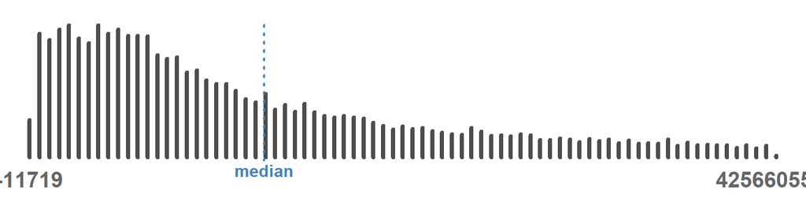

**DATA PREVIEW**:

| 786 | 1000 |
| --- | --- |
| 300 | 10000 |
| 397 | 19327 |
| 418 | 5000 |
| 80427 | 588 |
| 0 | 45638 |
| 48401 | 225 |
| 950 | 1140 |
| 41 | 4056 |
| 143 | 83437 |

#### F9_01_EXP_TOT_PY

**LABEL**: F9_01_EXP_TOT_PY

**DATA TYPE**: numeric

**SCOPE**:

**LENGTH**: 10

**DESCRIPTION**: Total expenses - prior year

**LOCATION CODE**:

**PROPERTIES**:

| STAT | VAL | PER |
| --- | --- | --- |
| Rows | 25000 |  |
| Distinct | 19931 |  |
| Most Common Value | 0 | (14%) |
| Zero | 3257 | (13%) |
| All Empty | 0 | (0%) |
| Missing/NA | 1377 | (5.5%) |
| Infinite | 0 | (0%) |

**QUANTILES**:

| STAT | VAL |
| --- | --- |
| Q - 05 | 0 |
| Q - 25 | 29,933 |
| Median | 102,618 |
| Q - 75 | 362,012.5 |
| Q - 95 | 5,357,595 |

**STATS**:

| STAT | VAL |
| --- | --- |
| Minimum | -5,437,471 |
| Median | 102,618 |
| Mean | 3,407,085 |
| Maximum | 4,624,922,368 |
| Skew | 48.26 |

**HIST**:

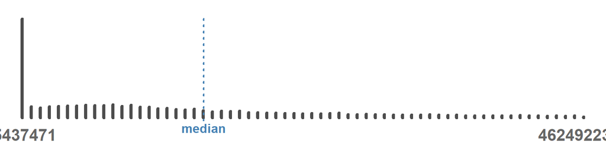

**DATA PREVIEW**:

| 3400 | 44039 |
| --- | --- |
| 7500 | 36 |
| 827 | 3200 |
| 2206 | 55199 |
| 1540 | 400 |
| 882 | 1220 |
| 0 | 78821 |
| 7191 | 656 |
| 7814 | 32965 |
| 8214 | 5791 |

## Character

#### F9_00_ORG_NAME_L1

**LABEL**: F9_00_ORG_NAME_L1

**DATA TYPE**: character

**SCOPE**:

**LENGTH**: 97

**DESCRIPTION**: Organization name line 1

**LOCATION CODE**:

**PROPERTIES**:

| STAT | VAL | PER |
| --- | --- | --- |
| Rows | 25000 |  |
| Distinct | 17455 |  |
| Most Common Value | NA | (NaN%) |
| Zero | 0 | (0%) |
| All Empty | 0 | (0%) |
| Missing/NA | 1378 | (5.5%) |
| Infinite | 0 | (0%) |

**PREVIEW**:

| AMERICAN FEDERATION OF TEACHERS | INTERNATIONAL BROTHERHOO |
| --- | --- |
| AMERICAN LEGION | KIWANIS INTERNATIONAL INC |
| BENEVOLENT & PROTECTIVE ORDER OF ELKS OF THE USA | KNIGHTS OF COLUMBUS |
| FRATERNAL ORDER OF EAGLES | ROTARY INTERNATIONAL |
| INTERNATIONAL ASSOCIATION OF FIRE FIGHTERS | UNITED STEELWORKERS |
| INTERNATIONAL ASSOCIATION OF LIONS CLUBS | VETERANS OF FOREIGN WARS OF THE UNITED STATES DE |

**STATS**:

| STAT | CHARACTERS | WORDS |
| --- | --- | --- |
| Minimum | 3 | 1 |
| Median | 34 | 5 |
| Mean | 35.64 | 5.08 |
| Max | 97 | 17 |
| Skew | 0.43 | 0.94 |

**Word Cloud**:

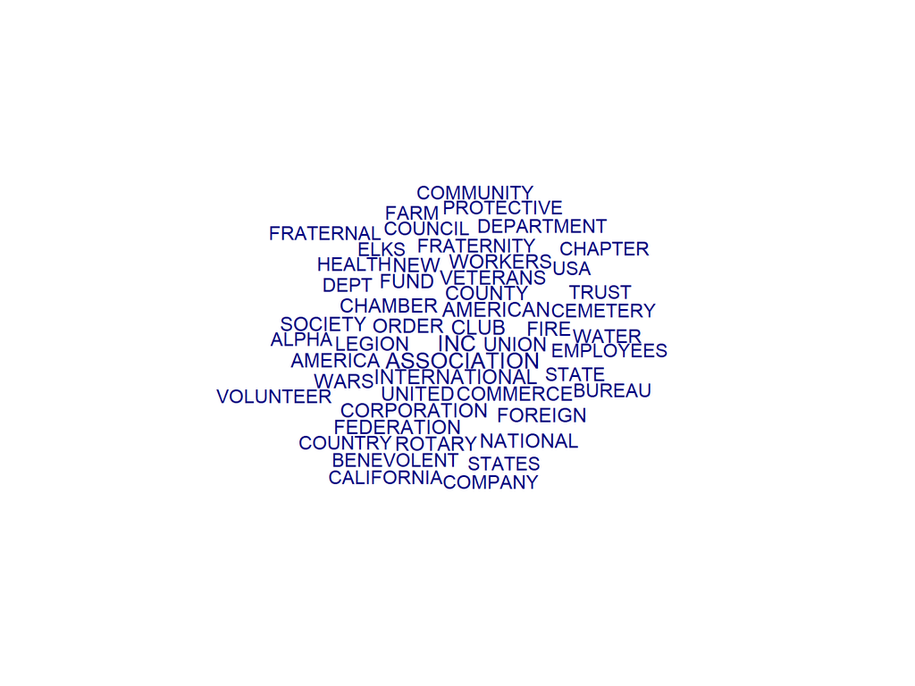

#### F0_00_ORG_CONTACT

**LABEL**: F0_00_ORG_CONTACT

**DATA TYPE**: character

**SCOPE**:

**LENGTH**: 33

**DESCRIPTION**: Contact person (from IRS files)

**LOCATION CODE**:

**PROPERTIES**:

| STAT | VAL | PER |
| --- | --- | --- |
| Rows | 25000 |  |
| Distinct | 10990 |  |
| Most Common Value | NA | (NaN%) |
| Zero | 0 | (0%) |
| All Empty | 0 | (0%) |
| Missing/NA | 13392 | (53.6%) |
| Infinite | 0 | (0%) |

**PREVIEW**:

| AGRECORDS | POST QUARTERMASTER |
| --- | --- |
| AIPSO | PRESIDENT |
| BOARD OF TRUSTEES | QUARTERMASTER |
| BRIANNE TILLOTSON | SCIARABBA WALKER |
| COMMANDER | SECRETARY |
| COMMERCE | SECRETARY TREASURER |
| CREST MANAGEMENT | SORORITY SOLUTIONS |
| FINANCIAL SECRETARY | THE BANK OF NEW YORK MELLON |
| GEO | THE ORGANIZATION |
| MIDAMERICA RET & ADMIN SOL INC | TREASURER |
| PEO TREASURER | WORTHY SECRETARY |

**STATS**:

| STAT | CHARACTERS | WORDS |
| --- | --- | --- |
| Minimum | 1 | 1 |
| Median | 14 | 2 |
| Mean | 15.02 | 2.49 |
| Max | 33 | 9 |
| Skew | 1.29 | 1.63 |

**Word Cloud**:

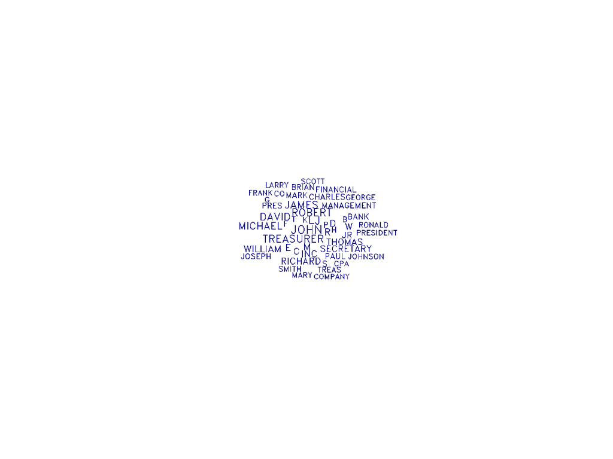

#### F9_00_ORG_ADDR_L1

**LABEL**: F9_00_ORG_ADDR_L1

**DATA TYPE**: character

**SCOPE**:

**LENGTH**: 35

**DESCRIPTION**: Organization street address line 1

**LOCATION CODE**:

**PROPERTIES**:

| STAT | VAL | PER |
| --- | --- | --- |
| Rows | 25000 |  |
| Distinct | 18785 |  |
| Most Common Value | NA | (NaN%) |
| Zero | 0 | (0%) |
| All Empty | 0 | (0%) |
| Missing/NA | 1378 | (5.5%) |
| Infinite | 0 | (0%) |

**PREVIEW**:

| 1154 TOWN AND COUNTRY COMMONS DR | PO BOX 24 |
| --- | --- |
| 3700 GRAND AVE | PO BOX 250 |
| 695 PRO MED LN STE 300 | PO BOX 26 |
| 9717 ELK GROVE FLORIN RD STE B | PO BOX 37 |
| PO BOX 1 | PO BOX 4 |
| PO BOX 111 | PO BOX 40 |
| PO BOX 123 | PO BOX 5 |
| PO BOX 151 | PO BOX 535007 |
| PO BOX 175 | PO BOX 6 |
| PO BOX 187 | PO BOX 66 |
| PO BOX 2 | PO BOX 8 |
| PO BOX 217 | PO BOX 86 |
| PO BOX 23 | PO BOX 9 |

**STATS**:

| STAT | CHARACTERS | WORDS |
| --- | --- | --- |
| Minimum | 2 | 1 |
| Median | 15 | 3 |
| Mean | 16.04 | 3.75 |
| Max | 35 | 9 |
| Skew | 0.97 | 1.42 |

**Word Cloud**:

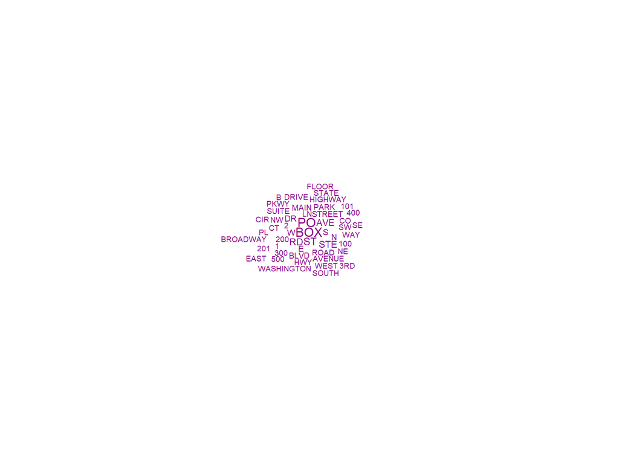

#### F9_00_ORG_ADDR_CITY

**LABEL**: F9_00_ORG_ADDR_CITY

**DATA TYPE**: character

**SCOPE**:

**LENGTH**: 22

**DESCRIPTION**: Organization city

**LOCATION CODE**:

**PROPERTIES**:

| STAT | VAL | PER |
| --- | --- | --- |
| Rows | 25000 |  |
| Distinct | 5986 |  |
| Most Common Value | NA | (NaN%) |
| Zero | 0 | (0%) |
| All Empty | 0 | (0%) |
| Missing/NA | 1378 | (5.5%) |
| Infinite | 0 | (0%) |

**PREVIEW**:

| ALBANY | LOS ANGELES |
| --- | --- |
| ALEXANDRIA | LOUISVILLE |
| ATLANTA | MADISON |
| AUSTIN | NEW YORK |
| BOSTON | PHILADELPHIA |
| CHICAGO | PHOENIX |
| CLEVELAND | PITTSBURGH |
| COLUMBIA | PORTLAND |
| COLUMBUS | RICHMOND |
| DALLAS | SACRAMENTO |
| DENVER | SAINT LOUIS |
| HONOLULU | SAN DIEGO |
| HOUSTON | SAN FRANCISCO |
| INDIANAPOLIS | SEATTLE |
| LAS VEGAS | SPRINGFIELD |
| LEXINGTON | WASHINGTON |

**STATS**:

| STAT | CHARACTERS | WORDS |
| --- | --- | --- |
| Minimum | 3 | 1 |
| Median | 9 | 1 |
| Mean | 8.69 | 1.26 |
| Max | 22 | 4 |
| Skew | 0.23 | 1.46 |

**Word Cloud**:

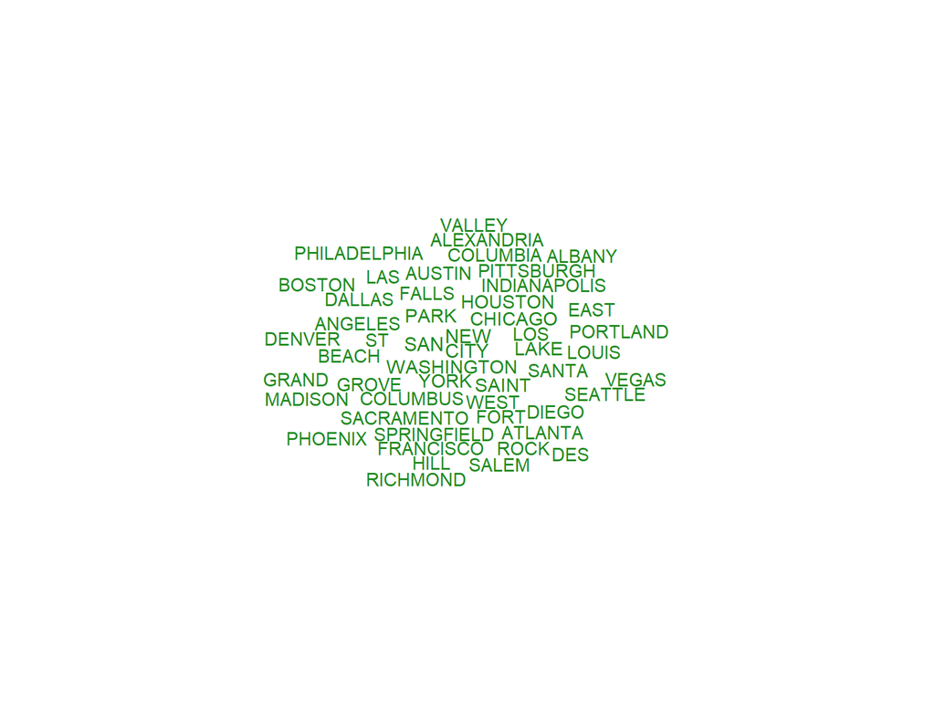

#### EIN

**LABEL**: EIN

**DATA TYPE**: character

**SCOPE**:

**LENGTH**: 9

**DESCRIPTION**: EIN

**LOCATION CODE**:

**PROPERTIES**:

| STAT | VAL | PER |
| --- | --- | --- |
| Rows | 25000 |  |
| Distinct | 24794 |  |
| Most Common Value | 010100593 | (0%) |
| Zero | 0 | (0%) |
| All Empty | 0 | (0%) |
| Missing/NA | 0 | (0%) |
| Infinite | 0 | (0%) |

**PREVIEW**:

| 010100593 | 010874048 |
| --- | --- |
| 010218055 | 010961458 |
| 010220588 | 016011483 |
| 010266289 | 016012302 |
| 010273431 | 016019950 |
| 010286963 | 016022337 |
| 010440702 | 016123853 |
| 010468398 | 020172119 |
| 010523313 | 020187390 |
| 010524078 | 020212092 |
| 010573723 | 020232424 |
| 010715375 | 020241397 |
| 010744517 | 020257793 |
| 010815981 | 020324779 |
| 010852125 | 020349390 |

**STATS**:

[output not shown]

**Word Cloud**:

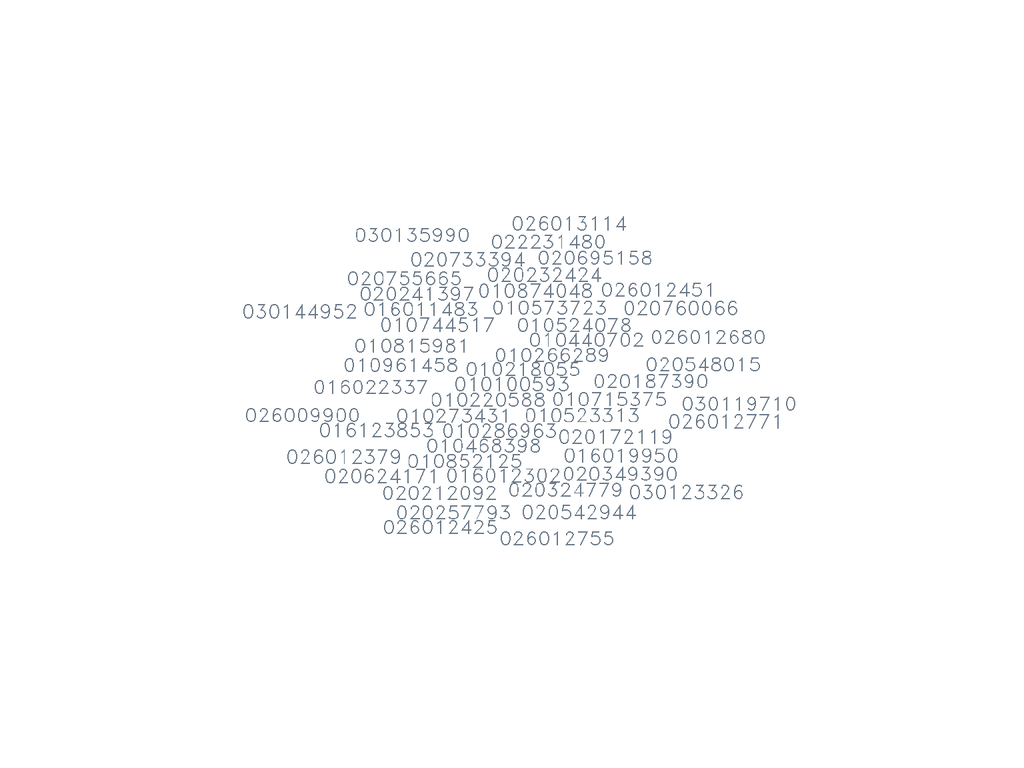

#### F9_00_TAX_PERIOD_BEGIN_DATE

**LABEL**: F9_00_TAX_PERIOD_BEGIN_DATE

**DATA TYPE**: character

**SCOPE**:

**LENGTH**: 6

**DESCRIPTION**: Tax period begin date

**LOCATION CODE**:

**PROPERTIES**:

[output not shown]

**PREVIEW**:

[output not shown]

**STATS**:

[output not shown]

**Word Cloud**:

[figure not shown]